# act_report

## Report: act_report

This report will cover only the insights and visualization section of project as shown below:

1. Insight#1: Puppo is the highest rating dog stage while pupper is lowest rating dog stage. Rating score of puppo is 26.2% while pupper rating score is 23.3%. As shown doggo took the second place with total rating equal to 25.3%

   Visualization #1:

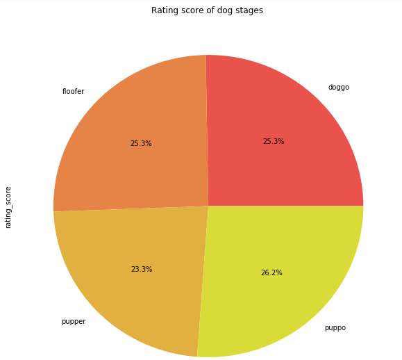

   Visualization #2:

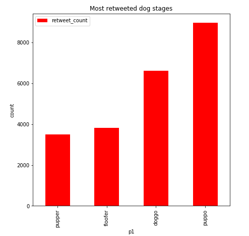

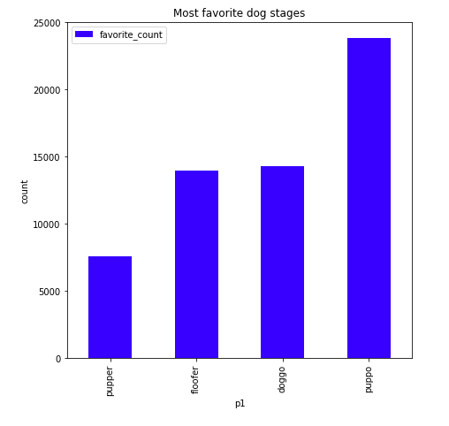

1. insight#3: Golden retriever is on the top of the prediction list of p1, casting more favorite and rating points in comparison to labrador retriever while labrador retriever casted more retweet comparing to the golden retriver total number of retweets.

   Visualization #3:

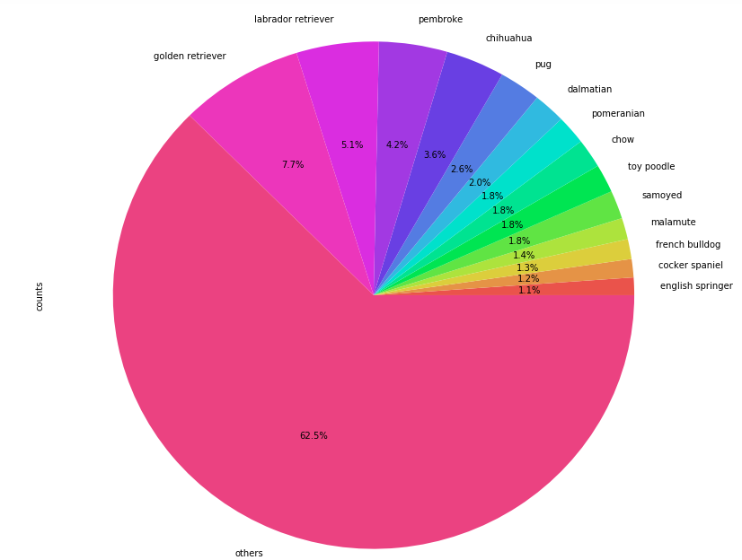